# Exercise 13.1

Lucia Camenisch

02 décembre 2022

First of all, we upload the necessary packages.

```r
library(data.table)   # data table, fread
library(ggplot2)      # plotting
library(dplyr)        # %>% function
library(tidyr)        # gather
library(e1071)        # skewness()
library(caret)        # confusionMatrix(), preProcess() for scaling data
library(ROCR)         # choosing optimal cutoff for logistic regression
library(fastDummies)  # turning categorical into dummies
library(FNN)          # compute k-NN
library(rpart)        # classification/regression trees
library(rpart.plot)   # plotting trees
library(knitr)        # r markdown
library(kableExtra)   # kable parameters

# sourcing homemade function for lift and decile charts (will be explained later in homework)
source("~/Documents/Travail/Business Analytics Master/Creating value through data mining/lift-decile-chart.R")

options(scipen = 999) # avoid scientific notation
```

The exploration of this dataset was done in exercise 7.2. We repeat it here.

We load our data, examine its structure using `str`, get a first idea of the variables distributions using `summary` and print a table of the number of unique values each variable takes.

```r
UniversalBank <- fread("UniversalBank.csv")                 # import data
str(UniversalBank)                                          # data structure
```

```
## Classes 'data.table' and 'data.frame':   5000 obs. of  14 variables:
##  $ ID                : int  1 2 3 4 5 6 7 8 9 10 ...
##  $ Age               : int  25 45 39 35 35 37 53 50 35 34 ...
##  $ Experience        : int  1 19 15 9 8 13 27 24 10 9 ...
##  $ Income            : int  49 34 11 100 45 29 72 22 81 180 ...
##  $ ZIP Code          : int  91107 90089 94720 94112 91330 92121 91711 93943 90089 93023 ...
##  $ Family            : int  4 3 1 1 4 4 2 1 3 1 ...
##  $ CCAvg             : num  1.6 1.5 1 2.7 1 0.4 1.5 0.3 0.6 8.9 ...
##  $ Education         : int  1 1 1 2 2 2 2 3 2 3 ...
##  $ Mortgage          : int  0 0 0 0 0 155 0 0 104 0 ...
##  $ Personal Loan     : int  0 0 0 0 0 0 0 0 0 1 ...
##  $ Securities Account: int  1 1 0 0 0 0 0 0 0 0 ...
##  $ CD Account        : int  0 0 0 0 0 0 0 0 0 0 ...
##  $ Online            : int  0 0 0 0 0 1 1 0 1 0 ...
##  $ CreditCard        : int  0 0 0 0 1 0 0 1 0 0 ...
##  - attr(*, ".internal.selfref")=<externalptr>
```

```r
summary(UniversalBank)                                      # data summary
```

```
##        ID            Age          Experience       Income          ZIP Code
##  Min.   :   1   Min.   :23.00   Min.   :-3.0   Min.   :  8.00   Min.   : 9307
##  1st Qu.:1251   1st Qu.:35.00   1st Qu.:10.0   1st Qu.: 39.00   1st Qu.:91911
##  Median :2500   Median :45.00   Median :20.0   Median : 64.00   Median :93437
##  Mean   :2500   Mean   :45.34   Mean   :20.1   Mean   : 73.77   Mean   :93152
##  3rd Qu.:3750   3rd Qu.:55.00   3rd Qu.:30.0   3rd Qu.: 98.00   3rd Qu.:94608
##  Max.   :5000   Max.   :67.00   Max.   :43.0   Max.   :224.00   Max.   :96651
##      Family          CCAvg          Education        Mortgage
##  Min.   :1.000   Min.   : 0.000   Min.   :1.000   Min.   :  0.0
##  1st Qu.:1.000   1st Qu.: 0.700   1st Qu.:1.000   1st Qu.:  0.0
##  Median :2.000   Median : 1.500   Median :2.000   Median :  0.0
##  Mean   :2.396   Mean   : 1.938   Mean   :1.881   Mean   : 56.5
##  3rd Qu.:3.000   3rd Qu.: 2.500   3rd Qu.:3.000   3rd Qu.:101.0
##  Max.   :4.000   Max.   :10.000   Max.   :3.000   Max.   :635.0
##  Personal Loan   Securities Account   CD Account         Online
##  Min.   :0.000   Min.   :0.0000     Min.   :0.0000   Min.   :0.0000
##  1st Qu.:0.000   1st Qu.:0.0000     1st Qu.:0.0000   1st Qu.:0.0000
##  Median :0.000   Median :0.0000     Median :0.0000   Median :1.0000
##  Mean   :0.096   Mean   :0.1044     Mean   :0.0604   Mean   :0.5968
##  3rd Qu.:0.000   3rd Qu.:0.0000     3rd Qu.:0.0000   3rd Qu.:1.0000
##  Max.   :1.000   Max.   :1.0000     Max.   :1.0000   Max.   :1.0000
##    CreditCard
##  Min.   :0.000
##  1st Qu.:0.000
##  Median :0.000
##  Mean   :0.294
##  3rd Qu.:1.000
##  Max.   :1.000
```

```r
t(t(sapply(UniversalBank, function(x) length(unique(x)))))  # number of unique values
```

```
##                    [,1]
## ID                 5000
## Age                  45
## Experience           47
## Income              162
## ZIP Code            467
## Family                4
## CCAvg               108
## Education             3
## Mortgage            347
## Personal Loan         2
## Securities Account    2
## CD Account            2
## Online                2
## CreditCard            2
```

We notice that all our variables have numerical values. Moreover, the five last variables are dummy variables.

By looking at the summary for `ZIP Code`, we notice that the minimum value, $9307$ is only four digits long.

We list all different ZIP Codes by ascending order:

```r
ZIPS = unique(UniversalBank[, 5]) # keeping only unique zips
setkey(ZIPS, "ZIP Code")          # ordering by zip number
ZIPS
```

```
##      ZIP Code
##   1:     9307
##   2:    90005
##   3:    90007
##   4:    90009
##   5:    90011
##  ---
## 463:    96091
## 464:    96094
## 465:    96145
## 466:    96150
## 467:    96651
```

```r
rm(ZIPS)                          # removing ZIPS from the environment as it won't be useful anymore.
```

This first ZIP Code is surely wrong. After a brief [internet research](https://en.wikipedia.org/wiki/List_of_ZIP_Code_prefixes#Starts_with_9), all these ZIP Codes seem to be for the state of California (USA) except for the last one, $96651$, which is for the military (naval/marine).

Another anomaly is found in the `Experience` variable:

```r
EXP = unique(UniversalBank[, 3])  # keeping only unique experience years
setkey(EXP, "Experience")         # ordering by experience
head(EXP, 9)                      # showing the first 9 rows of EXP
```

```
##    Experience
## 1:         -3
## 2:         -2
## 3:         -1
## 4:          0
## 5:          1
## 6:          2
## 7:          3
## 8:          4
## 9:          5
```

```r
rm(EXP)                           # removing EXP from the environment as it won't be useful anymore.
```

We see we have some negative values for years of experience, which seems unusual. Here are some potential explanations:

- Some values were erroneously attributed a minus sign, meaning that for example, -3 should be 3;
- Experience was translated by -3 by error, meaning that each experience value was subtracted by -3;
- Negative years of experience could maybe mean that the person is studying, meaning that for example, -3 would indicate that their working experience will start three years from now, when they finish studying;
- other random errors could have lead to this situation.

To understand the situation better, let’s look at histograms of `Age` with respect to different values for `Experience` (between -3 and 5)

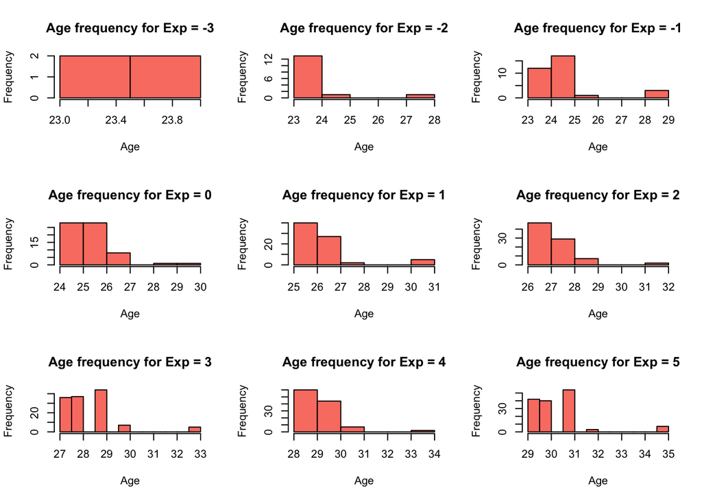

```r
par(mfrow = c(3, 3)) # 3x3 grid for the histograms

# loop iterates over years of experience
for (i in -3:5) {
  # plotting histogram for age distribution with year of experience fixed (using %in%)
  # the sprintf function allows to use the value of a variable inside a string,
  # it is a wrapper for a C function. This is useful for the titles of our plots.
  hist(UniversalBank[Experience %in% i, Age],
       main = sprintf("Age frequency for Exp = %i", i),
       xlab = "Age",
       col = "#FA8072")
}
```

```r
par(mfrow = c(1, 1)) # going back to normal 1x1 grid for plots
rm(i) # removing i index as it won't be useful anymore
```

We can deduce that the most common age at which people start working is 24 years old. This looks accurate for a population which is getting higher education.

The translation option evoked before is unlikely, as translating everyone by +3 again would mean that the age at which people start working would become 27, and this value seems too high.

Furthermore, we see that people with negative values for experience (-3, -2 and -1) overwhelmingly fall into the 23 and 24 age categories. This distribution indicates that random errors for negative values of experience are unlikely, because we wouldn’t get such a clear age distribution. These 23 and 24 year-olds could very well be students who will enter the workforce in 1, 2 or 3 years.

We choose to follow this hypothesis for the rest of this exercise.

Now, let us check if there are any missing values:

```r
t(t(colSums(is.na(UniversalBank)))) #number of missing values in each column
```

```
##                    [,1]
## ID                    0
## Age                   0
## Experience            0
## Income                0
## ZIP Code              0
## Family                0
## CCAvg                 0
## Education             0
## Mortgage              0
## Personal Loan         0
## Securities Account    0
## CD Account            0
## Online                0
## CreditCard            0
```

Fortunately, there are no missing values!

We can plot the distributions of each variable.

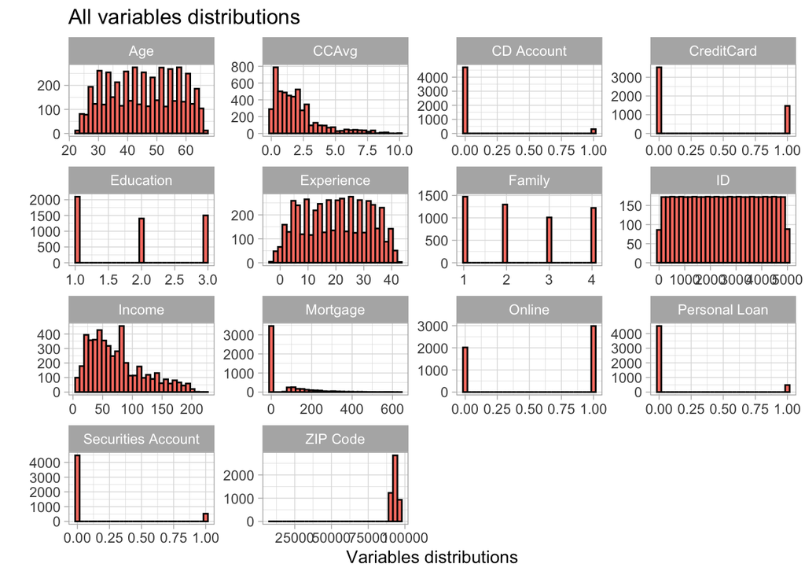

```r
UniversalBank %>% gather() %>%                        # gather transforms data into two columns with
                                                      # "key" and "value"
  ggplot(aes(value)) +                                # plotting the value
  facet_wrap(~ key, scales = "free") +                # making one plot for each key with facet
  geom_histogram(color = "black", fill = "#FA8072") + # making histograms
  theme_light() +                                     # aesthetic theme for our plots
  labs(x = "Variables distributions", y = "",         # label of the figure
       title = "All variables distributions")
```

We have our five dummy variables as well as `Education` and `Family` which take three and four different values respectively. These seven variables all take a few discrete different values. `Education` is surely a categorical variable. `Family`, on the other hand, probably represents the number of people in the family.

However, the maximal number is four, over 5000 observations. Either there are no families bigger than four in this data, or the variable might also be categorical, with the number four representing families of four or more people in the data. For the rest of this exercise. We will consider `Family` as numerical.

The distributions of `ID` and `ZIP Code` aren’t very interesting, since the IDs are uniformly distributed and we already have spotted the outlier in the `ZIP Code` distribution. We plot the histograms for the five remaining distributions in more detail, since the number of bins might have aggregated it too much.

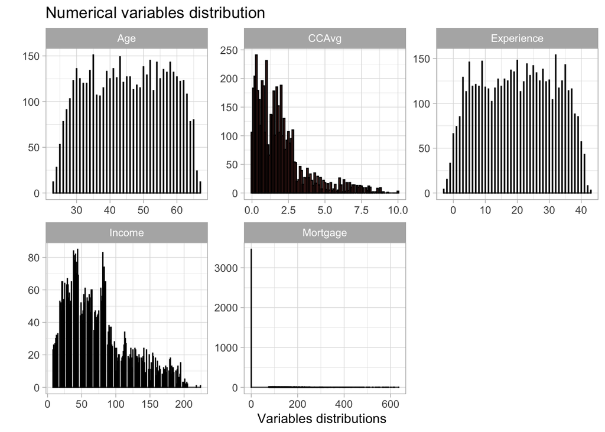

```r
# plotting with the same options as in the previous plot,
# except we set the width of bins to 0.1 to gain precision
UniversalBank[, c(2,3,4,7,9)] %>% gather() %>%
  ggplot(aes(value)) +
  facet_wrap(~ key, scales = "free") +
  geom_histogram(color = "black", fill = "#FA8072", binwidth = 0.1) +
  theme_light() +
  labs(x = "Variables distributions", y = "", title = "Numerical variables distribution")
```

As we mentioned, `CCAvg` and `Income` seem to be skewed variables. `Mortage` is more special, it has a huge gap with no values between 0 and 75 and 0 dwarfs all other values. We will look at the skewness index of `CCAvg` and `Income` and perform appropriate transformations. We won’t transform `Mortgage`.

To do so, we use `skewness()` from the `e1071` package. Generally, the index is interpreted as follows:

- **Around 0**: variable is symmetrical;
- **Above 0.5 in absolute value**: variable is moderately skewed;
- **Above 1 in absolute value**: variable is highly skewed;

```r
# looking at the skewness index, using sapply to use skewness() on multiple columns
sapply(UniversalBank[, list(Income, CCAvg)], skewness)
```

```
##    Income     CCAvg
## 0.8408339 1.5974844
```

```r
# transforming the variables
UniversalBank$Income <- sqrt(UniversalBank$Income)
UniversalBank$CCAvg <- log(UniversalBank$CCAvg + 1)

# recomputing skewness to see how it has evolved
sapply(UniversalBank[, list(Income, CCAvg)], skewness)
```

```
##    Income     CCAvg
## 0.2602795 0.3190323
```

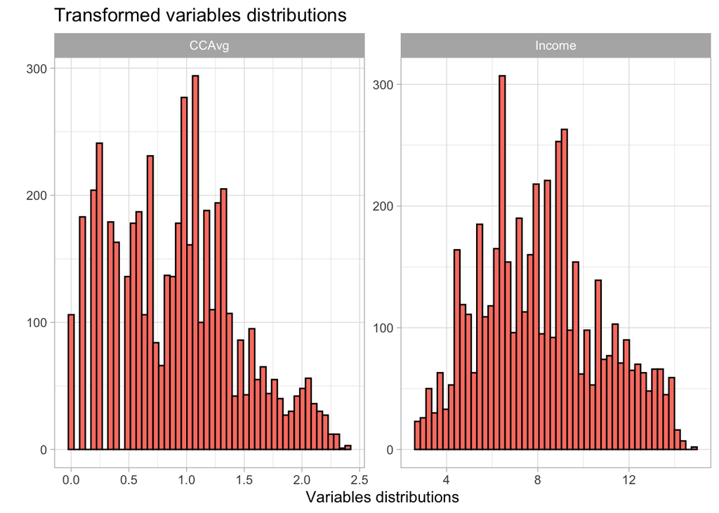

```r
# plotting the histograms of the variables to see the changes
UniversalBank[, list(Income, CCAvg)] %>% gather() %>%
  ggplot(aes(value)) +
  facet_wrap(~ key, scales = "free") +
  geom_histogram(color = "black", fill = "#FA8072", bins = 50) +
  theme_light() +
  labs(x = "Variables distributions", y = "", title = "Transformed variables distributions")
```

`Income` was moderately skewed, whereas `CCAvg` was highly skewed. We used a square root transformation on `Income` (it is less powerful than the log) and a logarithm transformation on `CCAvg`. As the minimal value of `CCAvg` is 0, we had to add 1 to the variable in order for the logarithm to be well-defined and positive on all our values.

After transforming, the skewness indexes dropped under 0.5 for both variables. Looking at the histograms, the distributions are indeed more symmetrical.

Now, we will get rid of `ID` and `ZIP Code` as those two variables won’t be used in our models. We also convert `Education` to a factor, since it is a categorical variable.

```r
UniversalBank <- UniversalBank[, `ZIP Code` := NULL]        # removing ZIP Code
UniversalBank <- UniversalBank[, ID := NULL]                # removing ID
UniversalBank$Education <- factor(UniversalBank$Education)  # Education as factor
```

We are now ready to partition our data into training (60%) and validation (40%) sets.

```r
# set seed for reproducing the partition
set.seed(111)

# generating training set index
train.index <- sample(c(1:nrow(UniversalBank)), 0.6*nrow(UniversalBank))
# generating validation set index as the complementary of training set
valid.index <- setdiff(c(1:nrow(UniversalBank)), train.index)

# creating data tables Train and Valid using the indexes
Train <- UniversalBank[train.index, ]
Valid <- UniversalBank[valid.index, ]

# removing indexes as they aren't used anymore
rm(train.index, valid.index)
```

# 1 Fit the three models to the data. Report the validation confusion matrix for each one.

## 1.1 Logistic regression

We start with the logistic regression, which is obtained by using the `glm()` function with option `family = "binomial"`. Then, we compute the predicted probabilities of our validation set using `predict()` with the `type = "response"` option.

```r
Logistic <- glm(`Personal Loan` ~. , data = Train, family = "binomial")   # logistic regression
summary(Logistic)                                                         # showing results
```

```
##
## Call:
## glm(formula = `Personal Loan` ~ ., family = "binomial", data = Train)
##
## Deviance Residuals:
##     Min       1Q   Median       3Q      Max
## -2.9309  -0.1592  -0.0429  -0.0085   4.2204
##
## Coefficients:
##                         Estimate  Std. Error z value             Pr(>|z|)
## (Intercept)          -20.5605948   2.6077546  -7.884 0.000000000000003160 ***
## Age                   -0.0272988   0.0875768  -0.312              0.75526
## Experience             0.0380976   0.0871689   0.437              0.66207
## Income                 1.3228094   0.0885240  14.943 < 0.0000000000000002 ***
## Family                 0.6497248   0.1051597   6.178 0.000000000647310800 ***
## CCAvg                  1.0689774   0.2386828   4.479 0.000007511524509696 ***
## Education2             3.8961232   0.3512549  11.092 < 0.0000000000000002 ***
## Education3             3.9108372   0.3493558  11.194 < 0.0000000000000002 ***
## Mortgage               0.0007114   0.0008016   0.887              0.37487
## `Securities Account`  -0.4459461   0.3808242  -1.171              0.24160
## `CD Account`           3.7890238   0.4666594   8.119 0.000000000000000468 ***
## Online                -0.6797987   0.2224969  -3.055              0.00225 **
## CreditCard            -1.1466572   0.2928684  -3.915 0.000090305420249074 ***
## ---
## Signif. codes:  0 '***' 0.001 '**' 0.01 '*' 0.05 '.' 0.1 ' ' 1
##
## (Dispersion parameter for binomial family taken to be 1)
##
##     Null deviance: 1915.10  on 2999  degrees of freedom
## Residual deviance:  636.24  on 2987  degrees of freedom
## AIC: 662.24
##
## Number of Fisher Scoring iterations: 8
```

```r
LogisticPred <- predict(Logistic, Valid, type = "response")               # probabilities of Valid
```

The logistic regression gives us probabilities that `Personal Loan = 1`. However, to classify each predicted value, we first need to choose a cutoff probability. As a default, the cutoff is set to 0.5.

However, we can also choose a cutoff which optimizes certain properties of our regression. For example, for each cutoff value, it is possible to compute the accuracy, sensitivity, specificity, etc. obtained from the confusion matrix.

That way, we can choose a cutoff value which gives the best trade off between sensitivity and specificity for our logistic regression. This is what we will do here.

In order to compute sensitivity and specificity for cutoff values $p_c \in [0,1]$, we will use functions `prediction` and `performance` from package `ROCR`.

```r
# prediction() creates an object of "formal class prediction" which contains information about the
# predicted probabilities and the actual values of the validation set.
Predictions = prediction(predictions = LogisticPred, labels = Valid$`Personal Loan`)
Predictions
```

```
## A prediction instance
##   with 2000 data points
```

```r
# our "formal class prediction" object serves as input for the performance() function.
# the second argument of performance will specify which characteristic should be computed with
# respect to the cutoff value. It computes the characteristic for 2000 different values of the cutoff
SensPerf = performance(Predictions, "sens")  # computing sensitivity wrt cutoff
SensPerf
```

```
## A performance instance
##   'Cutoff' vs. 'Sensitivity' (alpha: 'none')
##   with 2000 data points
```

```r
SpecPerf = performance(Predictions, "spec")  # computing specificity wrt cutoff
SpecPerf
```

```
## A performance instance
##   'Cutoff' vs. 'Specificity' (alpha: 'none')
##   with 2000 data points
```

```r
# SensPerf and SpecPerf are "formal class performance" objects.

# we create a data table which contains the cutoff, the sensitivity and the specificity values
CutSensSpec = data.table(     Cutoff = SensPerf@x.values[[1]],  # use @ to access content inside
                         Sensitivity = SensPerf@y.values[[1]],  # formal class (S4) objects
                         Specificity = SpecPerf@y.values[[1]])
head(CutSensSpec)  # showing the beginning of our table
```

```
##       Cutoff Sensitivity Specificity
## 1:       Inf 0.000000000           1
## 2: 0.9999131 0.005319149           1
## 3: 0.9993935 0.010638298           1
## 4: 0.9993647 0.015957447           1
## 5: 0.9993341 0.021276596           1
## 6: 0.9991134 0.026595745           1
```

```r
# We can see that the maximum value of the cutoff is defined as Inf in the table.
# We will change it to 1 so that it remains coherent with the probas and looks nice when plotting
CutSensSpec[1, 1] = 1
```

Now that we have our `CutSensSpec` table, we will plot sensitivity and specificity with respect to the cutoff value $p_c$.

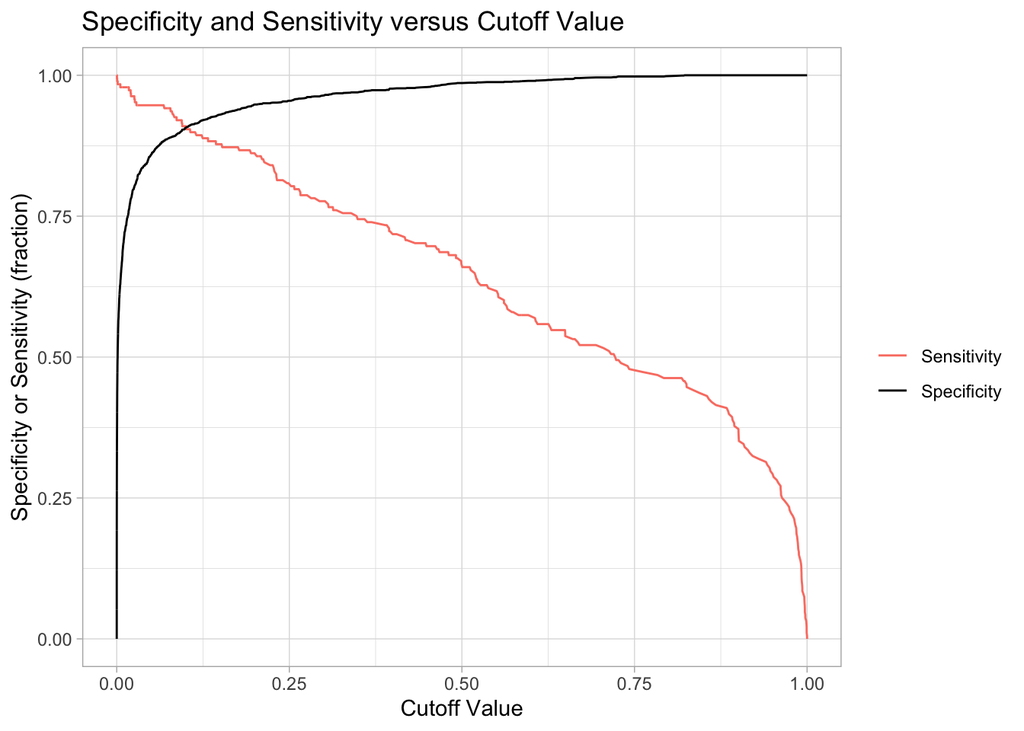

```r
CutSensSpec %>%
  gather(key = "variable", value = "value", -c(Cutoff)) %>%      # gathering data except Cutoff
  ggplot(aes(x = Cutoff, y = value)) +                           # plotting sens and spec wrt cutoff
  geom_path(aes(color = variable)) +                             # plotting as lines
  scale_color_manual(values = c("#FA8072", "black")) +           # different colors for sens and spec
  theme_light() +                                                # aesthetic theme of plot
  labs(x = "Cutoff Value",                                       # labels of the plot
       y = "Specificity or Sensitivity (fraction)",
       title = "Specificity and Sensitivity versus Cutoff Value",
       color = "")
```

As we can see in the plot, the best compromise between sensitivity and specificity will be where the two lines cross. That way, we will have both values around 90%.

In a business context, management might establish guidelines to follow on the importance of sensitivity vs specificity. For example, if the goal of the campaign is to catch most of the people susceptible to subscribe to the personal loan and we can accept that some false positives are also caught in the process, we could have a greater weight on sensitivity than specificity. On the contrary, if the wasted costs of targeting people who will not subscribe to the personal loan are big, we would put a greater weight on specificity than sensitivity.

Since we have no such insight here, we consider specificity and sensitivity to be equally important.

To find the cutoff value at the intersection of the two curves in our data table, which we will call `OptCutoff` (for optimal cutoff), we will add a column to `CutSensSpec`, called `Diff`. It will be defined as follows:

$$Diff = |Specificity -
Sensitivity|$$
Then, the optimal cutoff value will be the one which minimizes this difference, i.e. the minimal value of `Diff`.

```r
CutSensSpec[, Diff := abs(Specificity - Sensitivity)]   # creating Diff
MinDiff = CutSensSpec[Diff %in% min(Diff),]             # getting the line in table with OptCutoff
MinDiff
```

```
##       Cutoff Sensitivity Specificity      Diff
## 1: 0.1003923   0.9095745   0.9072848 0.0022897
```

```r
OptCutoff = as.numeric(MinDiff[1, 1])                   # getting OptCutoff
OptCutoff
```

```
## [1] 0.1003923
```

```r
# now that we have our cutoff, we can remove objects which won't be used anymore from our environment
rm(Predictions, SensPerf, SpecPerf, CutSensSpec, MinDiff)
```

Then, the cutoff probability we will use is around 10%. This is quite different from the default one at 50%. By looking at the plot, we can see that at 50%, the sensitivity is around 65%. This means that by using the default value, we would be missing 35% of people who would take a personal loan by not targeting them!

Now, we can use `OptCutoff` to classify records in our validation set and then compute our confusion matrix.

```r
# we transform the probabilities vector into a classes vector.
# Predicted probabilities above our cutoff will be assigned class 1, whereas probas below will be 0.
LogisticPred <- data.table(class = ifelse(LogisticPred >= OptCutoff, 1, 0),
                           probability = LogisticPred)
# we compute the confusion matrix, changing the values to factor so confusionMatrix works properly
# we specify that the class of interest is 1
CMLogistic = confusionMatrix(as.factor(LogisticPred$class),
                             as.factor(Valid$`Personal Loan`),
                             positive = "1")
CMLogistic
```

```
## Confusion Matrix and Statistics
##
##           Reference
## Prediction    0    1
##          0 1644   17
##          1  168  171
##
##                Accuracy : 0.9075
##                  95% CI : (0.8939, 0.9198)
##     No Information Rate : 0.906
##     P-Value [Acc > NIR] : 0.428
##
##                   Kappa : 0.6007
##
##  Mcnemar's Test P-Value : <0.0000000000000002
##
##             Sensitivity : 0.9096
##             Specificity : 0.9073
##          Pos Pred Value : 0.5044
##          Neg Pred Value : 0.9898
##              Prevalence : 0.0940
##          Detection Rate : 0.0855
##    Detection Prevalence : 0.1695
##       Balanced Accuracy : 0.9084
##
##        'Positive' Class : 1
##
```

We display the lift chart, using the method explained by the book in chapter 5:

1. Creating a data table which contains the probabilities and the actual class of each person in our validation set;
2. Ordering the table by probability in descending order;
3. Adding a cumulative column for actual classes;
4. Adding a column which numbers the observations 1, 2, 3, 4, …;
5. Plotting cumulative classes (y axis) with respect to number of observations (x axis);
6. Plotting the straight line by linking the first and last observations of our table together.

```r
# creating the table with column Prob and ActualClass
LiftTable <- data.table(Prob = LogisticPred$probability, ActualClass = Valid$`Personal Loan`)
# ordering the rows of the table with respect to Prob in descending order (minus sign)
LiftTable <- LiftTable[order(-Prob),]
# adding cumulative column called CumulClass
LiftTable <- LiftTable[, CumulClass := cumsum(ActualClass)]
# adding numbering class called Obs (from 1 to end of table)
LiftTable <- LiftTable[, Obs := 1:.N]

head (LiftTable) #displaying first rows of LiftTable
```

```
##         Prob ActualClass CumulClass Obs
## 1: 0.9999131           1          1   1
## 2: 0.9993935           1          2   2
## 3: 0.9993647           1          3   3
## 4: 0.9993341           1          4   4
## 5: 0.9991134           1          5   5
## 6: 0.9987355           1          6   6
```

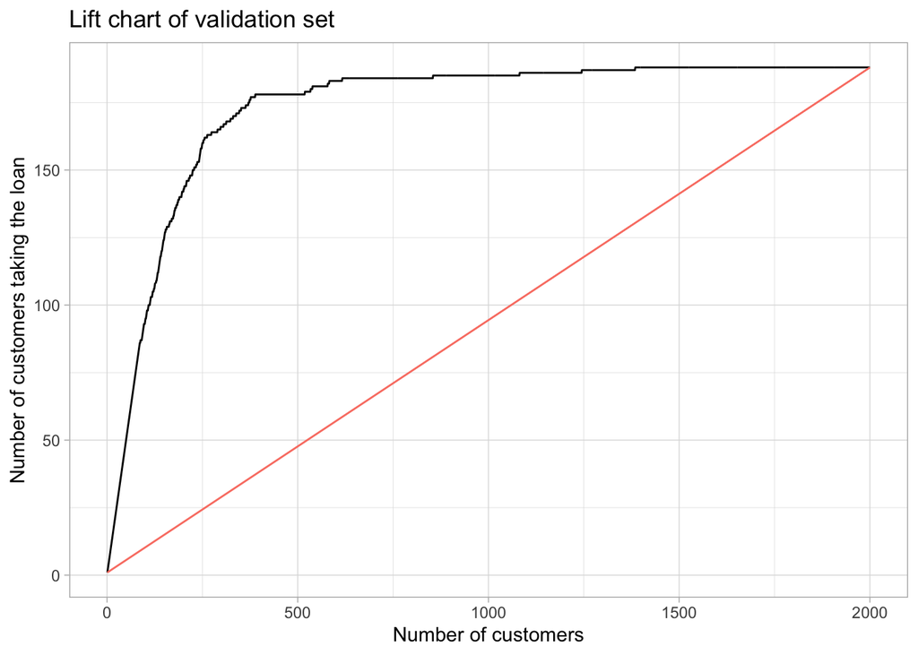

```r
ggplot(LiftTable, aes(x = Obs, y = CumulClass)) +              # plotting CumulClass wrt Obs
  geom_line() +                                                # lift curve
  geom_line(data = LiftTable[c(1, .N),], color = "#FA8072") +  # straight line
  theme_light() +                                              # aesthetic theme
  labs(x = "Number of customers",                              # text labels
       y = "Number of customers taking the loan",
       title = "Lift chart of validation set")
```

Now, we also create our decile chart. We use `LiftTable` to compute the mean of `ActualClass` by decile. This mean, divided by the global mean of `ActualClass`, will give us the mean response of each decile.

```r
# We create a decile table with a column numbering each decile (as a factor) and column MeanResp
# which we will fill later. For now, it contains zeros.
Deciles <- data.table(Decile = as.factor(1:10), MeanResp = numeric(10))
Deciles # displaying our table
```

```
##     Decile MeanResp
##  1:      1        0
##  2:      2        0
##  3:      3        0
##  4:      4        0
##  5:      5        0
##  6:      6        0
##  7:      7        0
##  8:      8        0
##  9:      9        0
## 10:     10        0
```

```r
# For each decile from 1 to 10:
for (i in 1:10){
  # We compute the mean of ActualClass for the deciles
  # ( (i-1)/10*.N+1 ):( i/10*.N ) selects columns 1 to 200, 201 to 400, etc.
  DecileMean = mean(LiftTable[( (i-1)/10*.N+1 ):( i/10*.N ), ActualClass])
  # we replace MeanResp in our Deciles table by the DecileMean divided by the global mean
  Deciles[i, 2] = DecileMean/mean(LiftTable$ActualClass)
}
Deciles # displaying our table with the correct mean response of each decile!
```

```
##     Decile   MeanResp
##  1:      1 7.55319149
##  2:      2 1.91489362
##  3:      3 0.26595745
##  4:      4 0.05319149
##  5:      5 0.05319149
##  6:      6 0.05319149
##  7:      7 0.10638298
##  8:      8 0.00000000
##  9:      9 0.00000000
## 10:     10 0.00000000
```

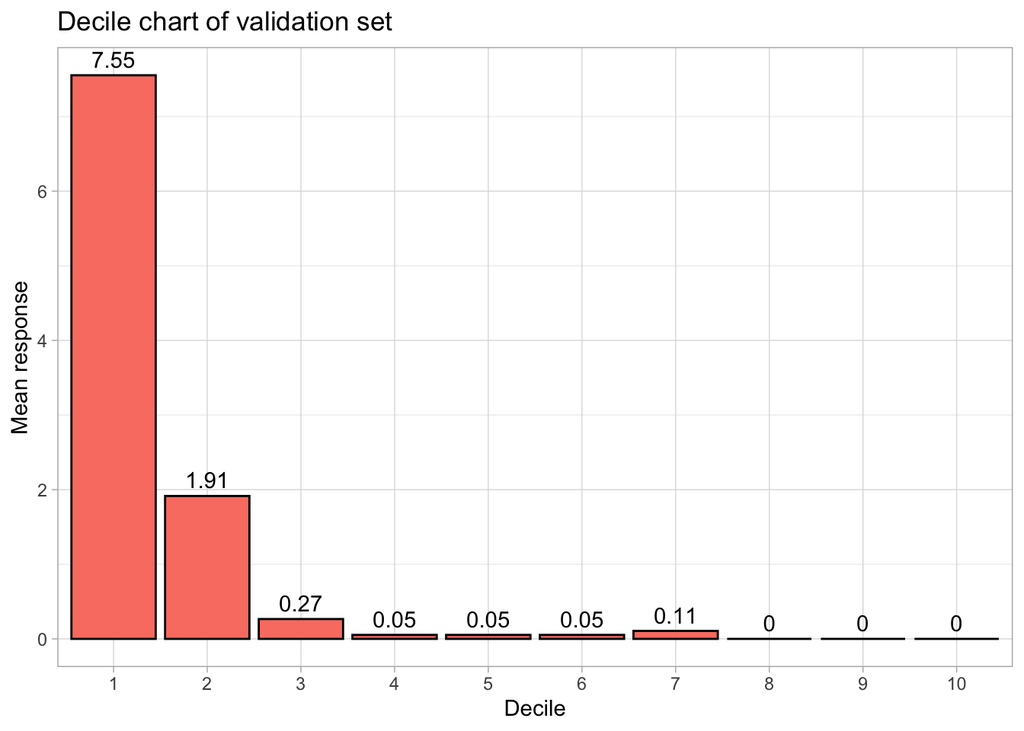

```r
ggplot(data = Deciles, aes(x = Decile, y = MeanResp)) +    # plotting decile chart
  geom_col(color = "black", fill = "#FA8072") +            # using geom_col
  theme_light() +
  labs(x = "Decile",
       y = "Mean response",
       title = "Decile chart of validation set") +
  geom_text(aes(label = round(MeanResp, 2)), vjust = -0.5) # adding percentage on top of bar
```

```r
# rm(LiftTable, Deciles, DecileMean, i) # these elements won't be used anymore
```

The two processes we used to plot our lift chart and decile chart will be turned into a homemade function, called `lift.decile.chart`, so we won’t have to manually go through each step every time. We explained the whole process here for transparency and to show that the process we followed is the one described by the book in chapter 5.

`lift.decile.chart` is sourced at the beginning of the file with packages and we will append it to the homework.

## 1.2 $k$-NN with $k = 3$

Now, we perform a $k$-NN algorithm with $k=3$. Before doing so, we need to scale the numerical variables inside our training set and convert `Education` to dummy variables, since it is categorical.

```r
# converting education inside Train and Valid
TrainkNN <- dummy_cols(Train, select_columns = "Education")
ValidkNN <- dummy_cols(Valid, select_columns = "Education")
# removing Education from TrainkNN and ValidkNN
TrainkNN <- TrainkNN[, Education := NULL]
ValidkNN <- ValidkNN[, Education := NULL]
```

```r
# preProcess from the caret package to compute means and sd on TrainkNN for scaling
norm.values <- preProcess(TrainkNN[, 1:6], method=c("center", "scale"))
# scaling TrainkNN and ValidkNN using predict and the scaling values we computed
TrainkNN[, 1:6] <- predict(norm.values, TrainkNN[, 1:6])
ValidkNN[, 1:6] <- predict(norm.values, ValidkNN[, 1:6])
```

We can now perform the $k$-NN algorithm.

```r
# performing knn from FNN package
kNNPred <- knn(train = TrainkNN[, -7], test = ValidkNN[, -7], cl = Train$`Personal Loan`,
               k = 3, prob = TRUE)   # we add prob = TRUE to get the probas of belonging to class
# we create a data table which has the class predictions and corresponding probas
kNNPred <- data.table(class = kNNPred, probability = attr(kNNPred, "prob"))
head(kNNPred)
```

```
##    class probability
## 1:     0   1.0000000
## 2:     0   1.0000000
## 3:     0   1.0000000
## 4:     0   1.0000000
## 5:     0   1.0000000
## 6:     0   0.6666667
```

The probabilities are all expressed as the chance of belonging to the predicted class. We change them to reflect the chance of belonging to class 1. This means that the probabilities of rows with class 1 remain unchanged, whereas rows with class 0 will have $1-p$ as probability.

```r
# if class = 0, we assign 1-p. else, we assign p.
kNNPred$probability <-ifelse(kNNPred$class == 0, 1-kNNPred$probability, kNNPred$probability)
head(kNNPred) # displaying kNNPred
```

```
##    class probability
## 1:     0   0.0000000
## 2:     0   0.0000000
## 3:     0   0.0000000
## 4:     0   0.0000000
## 5:     0   0.0000000
## 6:     0   0.3333333
```

However, the class was determined by $k$-NN with the default cutoff of 0.5. Since we have chosen the optimal cutoff for the logistic regression, we should go through the same process here to compare our models on fair grounds.

We repeat the process used to find the optimal cutoff.

```r
# we use exactly the same code as before.
Predictions = prediction(predictions = kNNPred$probability, labels = Valid$`Personal Loan`)

SensPerf = performance(Predictions, "sens")
SpecPerf = performance(Predictions, "spec")

CutSensSpec = data.table(     Cutoff = SensPerf@x.values[[1]],
                         Sensitivity = SensPerf@y.values[[1]],
                         Specificity = SpecPerf@y.values[[1]])

CutSensSpec[1, 1] = 1

CutSensSpec[, Diff := abs(Specificity - Sensitivity)]
OptCutoff = as.numeric(CutSensSpec[Diff %in% min(Diff),1])

# class is replaced with the new predictions according to our cutoff
kNNPred <- kNNPred[, class := ifelse(probability >= OptCutoff, 1, 0)]
```

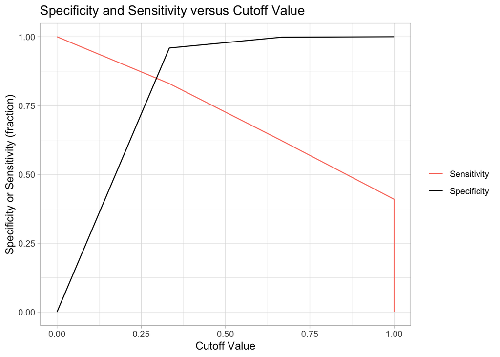

```r
CutSensSpec %>%
  gather(key = "variable", value = "value", -c(Cutoff, Diff)) %>%
  ggplot(aes(x = Cutoff, y = value)) +
  geom_path(aes(color = variable)) +
  scale_color_manual(values = c("#FA8072", "black")) +
  theme_light() +
  labs(x = "Cutoff Value",
       y = "Specificity or Sensitivity (fraction)",
       title = "Specificity and Sensitivity versus Cutoff Value",
       color = "")
```

```r
rm(Predictions, SensPerf, SpecPerf, CutSensSpec)
```

Here, `OptCutoff` will be 0.3333333.

Now, we compute the confusion matrix for $k$-NN.

```r
# computing the matrix as before
CMkNN = confusionMatrix(as.factor(kNNPred$class), as.factor(Valid$`Personal Loan`), positive = "1")
CMkNN
```

```
## Confusion Matrix and Statistics
##
##           Reference
## Prediction    0    1
##          0 1738   32
##          1   74  156
##
##                Accuracy : 0.947
##                  95% CI : (0.9363, 0.9564)
##     No Information Rate : 0.906
##     P-Value [Acc > NIR] : 0.000000000007995
##
##                   Kappa : 0.7172
##
##  Mcnemar's Test P-Value : 0.000068259585780
##
##             Sensitivity : 0.8298
##             Specificity : 0.9592
##          Pos Pred Value : 0.6783
##          Neg Pred Value : 0.9819
##              Prevalence : 0.0940
##          Detection Rate : 0.0780
##    Detection Prevalence : 0.1150
##       Balanced Accuracy : 0.8945
##
##        'Positive' Class : 1
##
```

We will now use our homemade function `lift.decile.chart` to display the lift and decile charts for the $k$-NN algorithm.

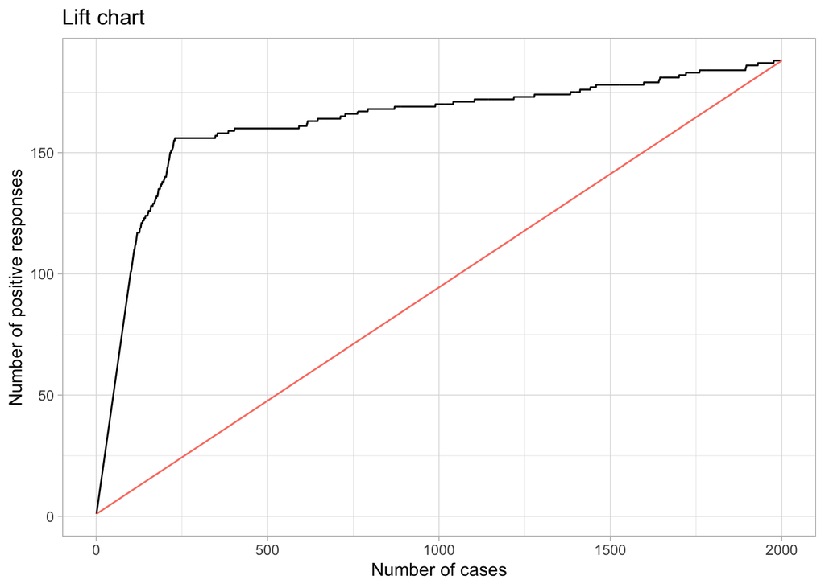

```r
lift.decile.chart(kNNPred$probability, Valid$`Personal Loan`, type = "lift")
```

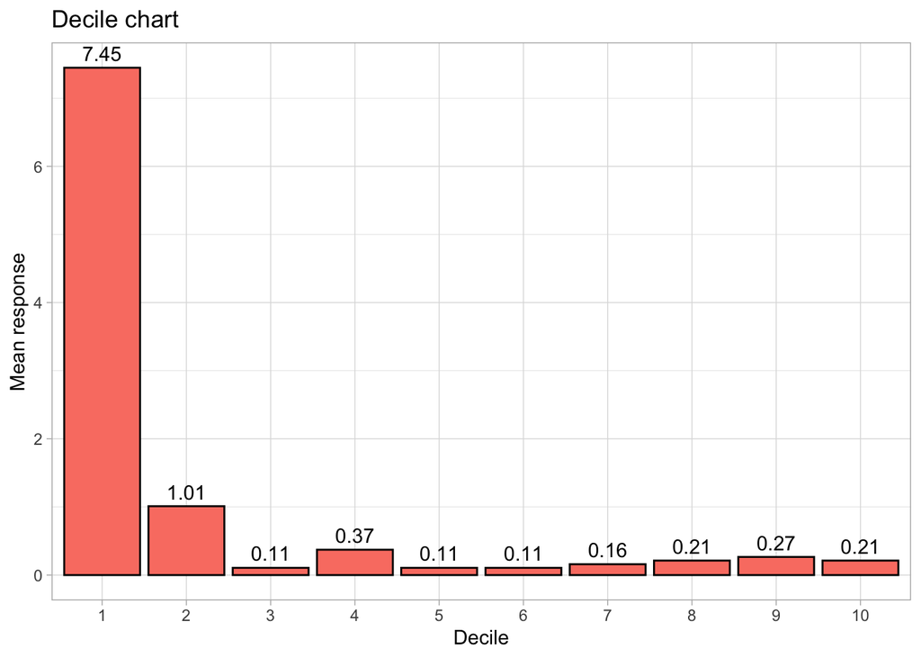

```r
lift.decile.chart(kNNPred$probability, Valid$`Personal Loan`, type = "decile")
```

## 1.3 Classification tree

For our classification tree, we use our `Train` and `Valid` sets. There is no need for normalization or creating dummies.

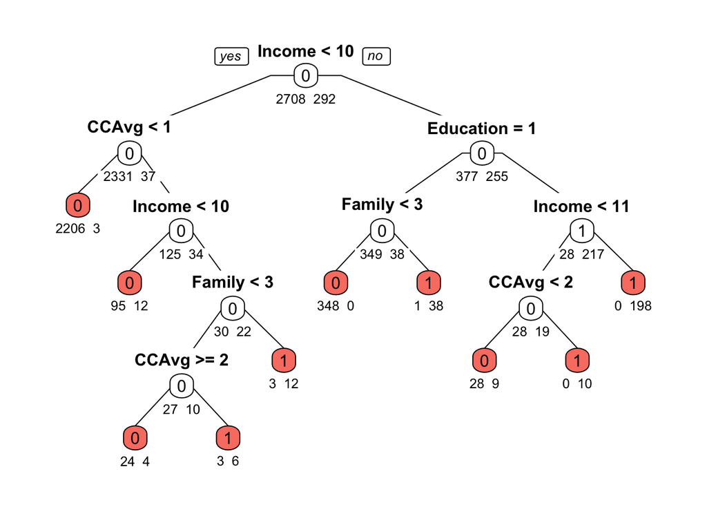

```r
# running the classification tree using the class method on training data
Tree <- rpart(`Personal Loan` ~ . , data = Train, method = "class")

# plotting the tree
prp(Tree, type = 1,                                                 # labels all nodes
    extra = 1,                                                      # displays n = ...
    varlen = -16,                                                   # number of chars of variables
    under = TRUE,                                                   # n = ... appears under node
    digits = -1,                                                    # avoid scientific notation
    box.col=ifelse(Tree$frame$var == "<leaf>", '#FA8072', 'white')) # coloring leaves in pink
```

We compute the predicted probabilities of the validation set.

```r
# using predict with type = "class" to predict the values of personal loan(with default cutoff)
# and with type = "prob" to get the probabilities.
# the values for class will be replaced by the ones we will compute once we set our optimal cutoff
TreePred <- data.table(class = predict(Tree, Valid, type = "class"),
                       probability = predict(Tree, Valid, type = "prob"))
head(TreePred) # we can see that we have probas for class 0 and 1. We keep only for class 1.
```

```
##    class probability.0 probability.1
## 1:     0     0.9986419   0.001358081
## 2:     0     0.9986419   0.001358081
## 3:     0     0.9986419   0.001358081
## 4:     0     0.9986419   0.001358081
## 5:     0     0.9986419   0.001358081
## 6:     1     0.0000000   1.000000000
```

```r
TreePred[, probability.0 := NULL]
```

As before, we will choose our optimal cutoff using the same method.

```r
# we use exactly the same steps as before.
Predictions = prediction(predictions = TreePred$probability.1, labels = Valid$`Personal Loan`)

SensPerf = performance(Predictions, "sens")
SpecPerf = performance(Predictions, "spec")

CutSensSpec = data.table(     Cutoff = SensPerf@x.values[[1]],
                         Sensitivity = SensPerf@y.values[[1]],
                         Specificity = SpecPerf@y.values[[1]])

CutSensSpec[1, 1] = 1

CutSensSpec[, Diff := abs(Specificity - Sensitivity)]
OptCutoff = as.numeric(CutSensSpec[Diff %in% min(Diff),1])

# class is replaced with the new predictions according to our cutoff
TreePred <- TreePred[, class := ifelse(probability.1 >= OptCutoff, 1, 0)]
```

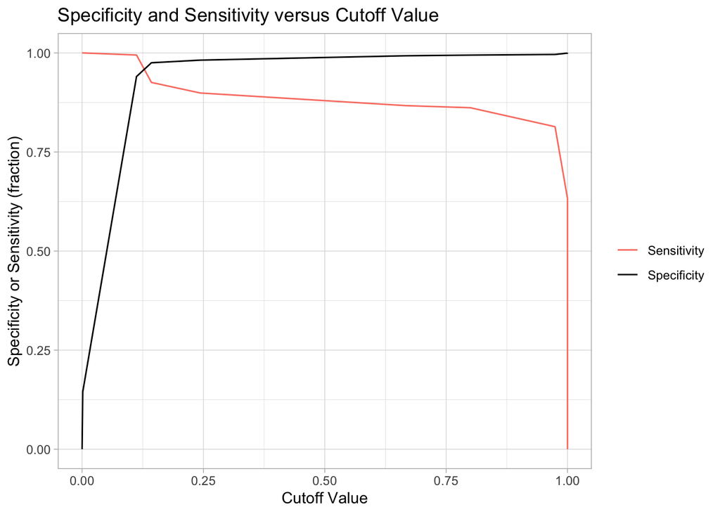

```r
CutSensSpec %>%
  gather(key = "variable", value = "value", -c(Cutoff, Diff)) %>%
  ggplot(aes(x = Cutoff, y = value)) +
  geom_path(aes(color = variable)) +
  scale_color_manual(values = c("#FA8072", "black")) +
  theme_light() +
  labs(x = "Cutoff Value",
       y = "Specificity or Sensitivity (fraction)",
       title = "Specificity and Sensitivity versus Cutoff Value",
       color = "")
```

```r
rm(Predictions, SensPerf, SpecPerf, CutSensSpec)
```

Now, `OptCutoff` is equal to 0.1428571. We compute the confusion matrix.

```r
# computing the confusion matrix as before
CMTree <- confusionMatrix(as.factor(TreePred$class), as.factor(Valid$`Personal Loan`), positive = "1")
CMTree
```

```
## Confusion Matrix and Statistics
##
##           Reference
## Prediction    0    1
##          0 1767   14
##          1   45  174
##
##                Accuracy : 0.9705
##                  95% CI : (0.9621, 0.9775)
##     No Information Rate : 0.906
##     P-Value [Acc > NIR] : < 0.00000000000000022
##
##                   Kappa : 0.8387
##
##  Mcnemar's Test P-Value : 0.00009397
##
##             Sensitivity : 0.9255
##             Specificity : 0.9752
##          Pos Pred Value : 0.7945
##          Neg Pred Value : 0.9921
##              Prevalence : 0.0940
##          Detection Rate : 0.0870
##    Detection Prevalence : 0.1095
##       Balanced Accuracy : 0.9503
##
##        'Positive' Class : 1
##
```

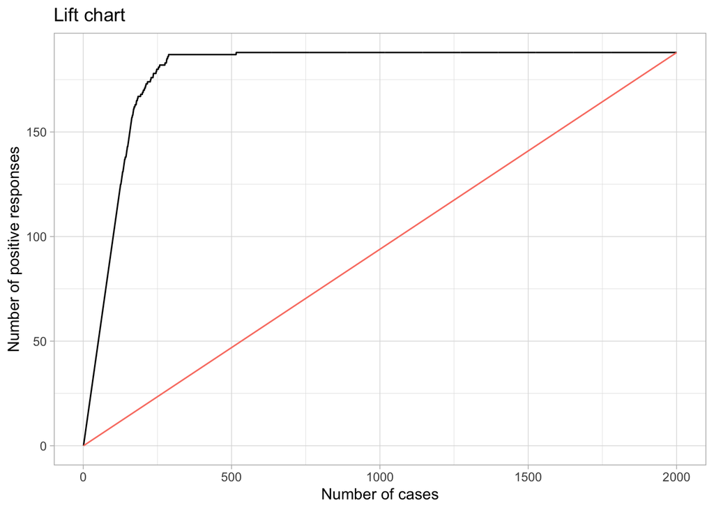

```r
lift.decile.chart(TreePred$probability.1, Valid$`Personal Loan`, type = "lift")
```

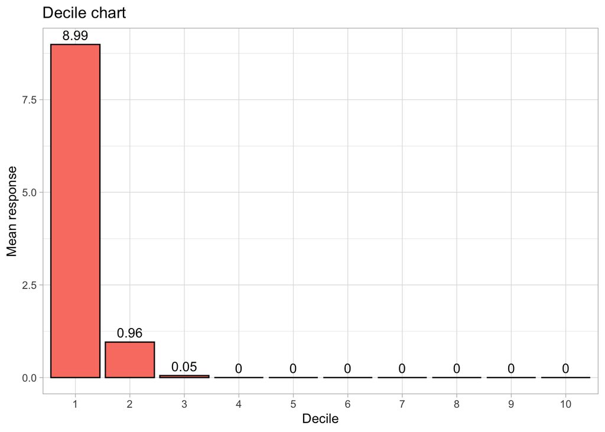

```r
lift.decile.chart(TreePred$probability.1, Valid$`Personal Loan`, type = "decile")
```

# 2 Create a data frame with the actual outcome and the predicted outcome for each of the three models.

We create a data frame which contains:

- `Value`: the actual outcome;
- `LogisticPred`, `kNNPred` and `TreePred`: the predicted outcomes;
- `LogisticProb`, `kNNProb` and `TreeProb`: the predicted probabilities.

```r
ModelsPredictions = data.table(Values = Valid$`Personal Loan`,
                               LogisticPred = LogisticPred$class,
                               kNNPred = kNNPred$class,
                               TreePred = TreePred$class,
                               LogisticProb = LogisticPred$probability,
                               kNNProb = kNNPred$probability,
                               TreeProb = TreePred$probability.1)

# displaying first 10 rows with kable
kable_styling(kable(head(ModelsPredictions, n = 10)), full_width = FALSE)
```

| Values | LogisticPred | kNNPred | TreePred | LogisticProb | kNNProb | TreeProb |
| --- | --- | --- | --- | --- | --- | --- |
| 0 | 0 | 0 | 0 | 0.0000190 | 0.0000000 | 0.0013581 |
| 0 | 1 | 0 | 0 | 0.1191341 | 0.0000000 | 0.0013581 |
| 0 | 0 | 0 | 0 | 0.0000149 | 0.0000000 | 0.0013581 |
| 0 | 0 | 0 | 0 | 0.0296588 | 0.0000000 | 0.0013581 |
| 0 | 0 | 0 | 0 | 0.0008924 | 0.0000000 | 0.0013581 |
| 0 | 1 | 1 | 1 | 0.3941745 | 0.3333333 | 1.0000000 |
| 0 | 0 | 0 | 0 | 0.0042773 | 0.0000000 | 0.0000000 |
| 0 | 0 | 0 | 0 | 0.0000146 | 0.0000000 | 0.0013581 |
| 0 | 0 | 0 | 0 | 0.0142884 | 0.0000000 | 0.0013581 |
| 0 | 0 | 0 | 0 | 0.0546383 | 0.0000000 | 0.0000000 |

# 3 Add two columns to this data frame for a majority vote of predicted outcomes, and the average of the predicted probabilities.

We add the two columns, called `Vote` and `MeanProb`.

```r
# Vote computes taking the average of the three predictions and rounding it to 0 or 1
ModelsPredictions[, Vote := round((LogisticPred + kNNPred + TreePred)/3)]
# MeanProb computes the average of the three probabilities
ModelsPredictions[, MeanProb := (LogisticProb + kNNProb + TreeProb)/3]
```

`Vote` directly gives us the resulting class.

However, we need to classify records based on the mean probability we have obtained. We will repeat the same process as before to get the optimal cutoff.

```r
# we use exactly the same steps as before.
Predictions = prediction(predictions = ModelsPredictions$MeanProb, labels = Valid$`Personal Loan`)

SensPerf = performance(Predictions, "sens")
SpecPerf = performance(Predictions, "spec")

CutSensSpec = data.table(     Cutoff = SensPerf@x.values[[1]],
                         Sensitivity = SensPerf@y.values[[1]],
                         Specificity = SpecPerf@y.values[[1]])

CutSensSpec[1, 1] = 1

CutSensSpec[, Diff := abs(Specificity - Sensitivity)]
OptCutoff = as.numeric(CutSensSpec[Diff %in% min(Diff),1])

ModelsPredictions <- ModelsPredictions[, ProbClass := ifelse(MeanProb >= OptCutoff, 1, 0)]
```

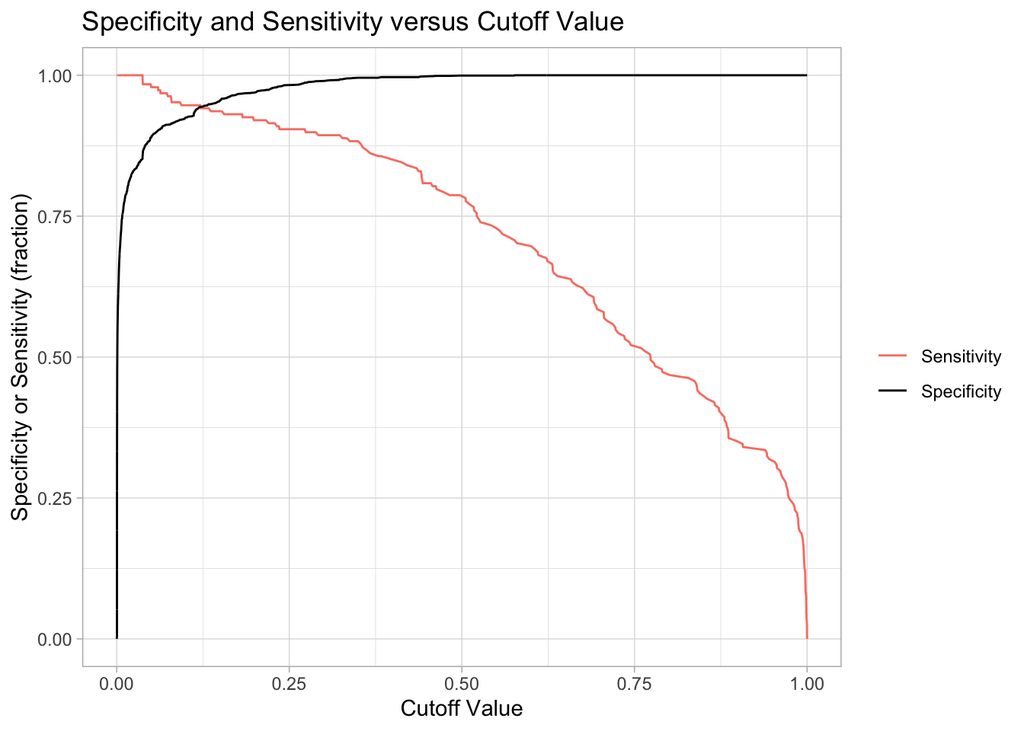

```r
CutSensSpec %>%
  gather(key = "variable", value = "value", -c(Cutoff, Diff)) %>%
  ggplot(aes(x = Cutoff, y = value)) +
  geom_path(aes(color = variable)) +
  scale_color_manual(values = c("#FA8072", "black")) +
  theme_light() +
  labs(x = "Cutoff Value",
       y = "Specificity or Sensitivity (fraction)",
       title = "Specificity and Sensitivity versus Cutoff Value",
       color = "")
```

```r
rm(Predictions, SensPerf, SpecPerf, CutSensSpec)
```

The optimal cutoff is 0.121548.

Now that we have classified our records with respect to the optimal cutoff, we compute the confusion matrices for `ProbClass` and `Vote`.

```r
CMProbs = confusionMatrix(as.factor(ModelsPredictions$ProbClass),
                             as.factor(ModelsPredictions$Values),
                             positive = "1")
CMProbs
```

```
## Confusion Matrix and Statistics
##
##           Reference
## Prediction    0    1
##          0 1710   11
##          1  102  177
##
##                Accuracy : 0.9435
##                  95% CI : (0.9325, 0.9532)
##     No Information Rate : 0.906
##     P-Value [Acc > NIR] : 0.0000000004989
##
##                   Kappa : 0.7274
##
##  Mcnemar's Test P-Value : < 0.00000000000000022
##
##             Sensitivity : 0.9415
##             Specificity : 0.9437
##          Pos Pred Value : 0.6344
##          Neg Pred Value : 0.9936
##              Prevalence : 0.0940
##          Detection Rate : 0.0885
##    Detection Prevalence : 0.1395
##       Balanced Accuracy : 0.9426
##
##        'Positive' Class : 1
##
```

```r
CMVote = confusionMatrix(as.factor(ModelsPredictions$Vote),
                             as.factor(ModelsPredictions$Values),
                             positive = "1")
CMVote
```

```
## Confusion Matrix and Statistics
##
##           Reference
## Prediction    0    1
##          0 1761   16
##          1   51  172
##
##                Accuracy : 0.9665
##                  95% CI : (0.9576, 0.9739)
##     No Information Rate : 0.906
##     P-Value [Acc > NIR] : < 0.00000000000000022
##
##                   Kappa : 0.8185
##
##  Mcnemar's Test P-Value : 0.00003271
##
##             Sensitivity : 0.9149
##             Specificity : 0.9719
##          Pos Pred Value : 0.7713
##          Neg Pred Value : 0.9910
##              Prevalence : 0.0940
##          Detection Rate : 0.0860
##    Detection Prevalence : 0.1115
##       Balanced Accuracy : 0.9434
##
##        'Positive' Class : 1
##
```

Let us display all our confusion five matrices:

```r
CMLogistic$table
```

```
##           Reference
## Prediction    0    1
##          0 1644   17
##          1  168  171
```

```r
CMkNN$table
```

```
##           Reference
## Prediction    0    1
##          0 1738   32
##          1   74  156
```

```r
CMTree$table
```

```
##           Reference
## Prediction    0    1
##          0 1767   14
##          1   45  174
```

```r
CMProbs$table
```

```
##           Reference
## Prediction    0    1
##          0 1710   11
##          1  102  177
```

```r
CMVote$table
```

```
##           Reference
## Prediction    0    1
##          0 1761   16
##          1   51  172
```

We now display a table with the accuracy, sensitivity and specificity of each model.

```r
# displaying it as a data table passed inside kable()
kable_styling(kable(
  data.table(c("Logistic regression", "3-NN", "Classification tree", "Mean probabilities", "Vote"),
             c(CMLogistic$overall[1], CMkNN$overall[1], CMTree$overall[1], CMProbs$overall[1],
               CMVote$overall[1]),    # accuracy in each confusion matrix
             c(CMLogistic$byClass[1], CMkNN$byClass[1], CMTree$byClass[1], CMProbs$byClass[1],
               CMVote$byClass[1]),    # sensitivity in each confusion matrix
             c(CMLogistic$byClass[2], CMkNN$byClass[2], CMTree$byClass[2], CMProbs$byClass[2],
               CMVote$byClass[2])     # specificity in each confusion matrix
             ),
  col.names = c("Model", "Accuracy", "Sensitivity", "Specificity")), full_width = FALSE)
```

| Model | Accuracy | Sensitivity | Specificity |
| --- | --- | --- | --- |
| Logistic regression | 0.9075 | 0.9095745 | 0.9072848 |
| 3-NN | 0.9470 | 0.8297872 | 0.9591611 |
| Classification tree | 0.9705 | 0.9255319 | 0.9751656 |
| Mean probabilities | 0.9435 | 0.9414894 | 0.9437086 |
| Vote | 0.9665 | 0.9148936 | 0.9718543 |

We can see that the model with the highest accuracy is the classification tree. It also has the highest specificity and the second highest sensitivity. The other interesting model is the mean probabilities, since it has the highest sensitivity. It seems to be the most balanced between the three parameters, as all three are around 0.94.

We would choose between those two depending on preference. If the goal is to have the highest detection power of positive classes, then the mean probabilities model, with the highest sensitivity, would be chosen. If accuracy or specificity are more important, we would choose the tree model.

We should mention that by choosing the optimal cutoffs, we globally put more importance on sensitivity at the expense of the overall accuracy of the models, because more records will become false positives when we increase sensitivity. However, we can see that the accuracy levels all stay quite high, above 90%. I think this is a small sacrifice for an increase in sensitivity that is between 10% and 25% depending on the model.

# 4 Compare the error rates for the three individual methods and the two ensemble methods.

The error rate is exactly $1-Accuracy$, meaning that we can easily compute it. We add a column to our previous table.

```r
kable_styling(kable(
  data.table(c("Logistic regression", "3-NN", "Classification tree", "Mean probabilities", "Vote"),
             c(CMLogistic$overall[1], CMkNN$overall[1], CMTree$overall[1], CMProbs$overall[1],
               CMVote$overall[1]),    # accuracy in each confusion matrix
             rep(1,5)-c(CMLogistic$overall[1], CMkNN$overall[1], CMTree$overall[1],
                        CMProbs$overall[1], CMVote$overall[1]),
             # error rate computed doing 1-accuracy
             c(CMLogistic$byClass[1], CMkNN$byClass[1], CMTree$byClass[1], CMProbs$byClass[1],
               CMVote$byClass[1]),    # sensitivity in each confusion matrix
             c(CMLogistic$byClass[2], CMkNN$byClass[2], CMTree$byClass[2], CMProbs$byClass[2],
               CMVote$byClass[2])     # specificity in each confusion matrix
             ),
  col.names = c("Model", "Accuracy", "Error Rate", "Sensitivity", "Specificity")), full_width = FALSE)
```

| Model | Accuracy | Error Rate | Sensitivity | Specificity |
| --- | --- | --- | --- | --- |
| Logistic regression | 0.9075 | 0.0925 | 0.9095745 | 0.9072848 |
| 3-NN | 0.9470 | 0.0530 | 0.8297872 | 0.9591611 |
| Classification tree | 0.9705 | 0.0295 | 0.9255319 | 0.9751656 |
| Mean probabilities | 0.9435 | 0.0565 | 0.9414894 | 0.9437086 |
| Vote | 0.9665 | 0.0335 | 0.9148936 | 0.9718543 |

The classification tree is the method with the smallest error rate. It is followed by the voting method. $3$-NN and the mean probabilities models have very close error rates. The logistic regression clearly has the biggest error rate amongst all methods. From the point of view of error rates, ensembles methods overall don’t perform particularly better compared to individual methods.